# Lab 5: Interactions: Graphing & Regressions

Wednesday Bushong

3/7/2017

# Overview

Today we’ll learn about testing all kinds of interactions and plotting them.

# The Data

```r
library(rgl)
library(ggplot2)
d <- read.csv("InteractionData.csv")
```

# Categorical x Categorical Interactions

## Plotting

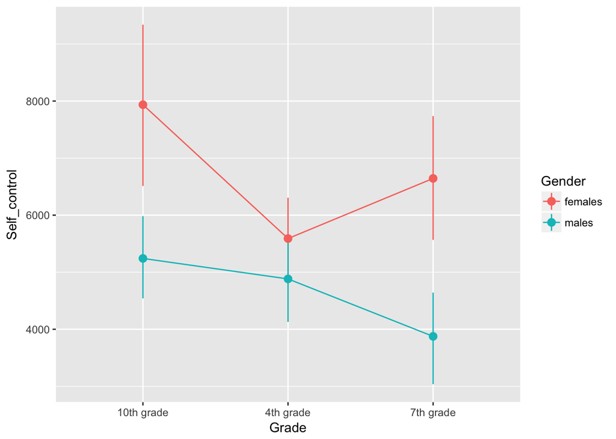

```r
p.gender.grade <- ggplot(d, aes(x = Grade, y = Self_control, color = Gender, group = Gender)) +
  stat_summary(fun.data = "mean_cl_boot", geom = "pointrange") +
  stat_summary(fun.y = "mean", geom = "line")
p.gender.grade
```

## Regressions

### Testing for interactions

```r
m.gender.grade <- lm(Self_control ~ Gender * Grade, d)
summary(m.gender.grade)
```

```
##
## Call:
## lm(formula = Self_control ~ Gender * Grade, data = d)
##
## Residuals:
##     Min      1Q  Median      3Q     Max
## -4967.0 -1379.5   -83.5  1441.8  5514.2
##
## Coefficients:
##                            Estimate Std. Error t value Pr(>|t|)
## (Intercept)                 7936.08     514.36  15.429  < 2e-16 ***
## Gendermales                -2694.69     738.70  -3.648 0.000434 ***
## Grade4th grade             -2346.15     727.42  -3.225 0.001732 **
## Grade7th grade             -1291.98     738.70  -1.749 0.083555 .
## Gendermales:Grade4th grade  1987.20    1036.73   1.917 0.058301 .
## Gendermales:Grade7th grade   -73.99    1044.68  -0.071 0.943686
## ---
## Signif. codes:  0 '***' 0.001 '**' 0.01 '*' 0.05 '.' 0.1 ' ' 1
##
## Residual standard error: 2121 on 94 degrees of freedom
## Multiple R-squared:  0.2877, Adjusted R-squared:  0.2498
## F-statistic: 7.594 on 5 and 94 DF,  p-value: 4.986e-06
```

### Testing simple slopes/simple effects

```r
m.gender.grade <- lm(Self_control ~ Gender * Grade, d)
summary(m.gender.grade)
```

```
##
## Call:
## lm(formula = Self_control ~ Gender * Grade, data = d)
##
## Residuals:
##     Min      1Q  Median      3Q     Max
## -4967.0 -1379.5   -83.5  1441.8  5514.2
##
## Coefficients:
##                            Estimate Std. Error t value Pr(>|t|)
## (Intercept)                 7936.08     514.36  15.429  < 2e-16 ***
## Gendermales                -2694.69     738.70  -3.648 0.000434 ***
## Grade4th grade             -2346.15     727.42  -3.225 0.001732 **
## Grade7th grade             -1291.98     738.70  -1.749 0.083555 .
## Gendermales:Grade4th grade  1987.20    1036.73   1.917 0.058301 .
## Gendermales:Grade7th grade   -73.99    1044.68  -0.071 0.943686
## ---
## Signif. codes:  0 '***' 0.001 '**' 0.01 '*' 0.05 '.' 0.1 ' ' 1
##
## Residual standard error: 2121 on 94 degrees of freedom
## Multiple R-squared:  0.2877, Adjusted R-squared:  0.2498
## F-statistic: 7.594 on 5 and 94 DF,  p-value: 4.986e-06
```

# Categorical x Continuous Interactions

## Plotting

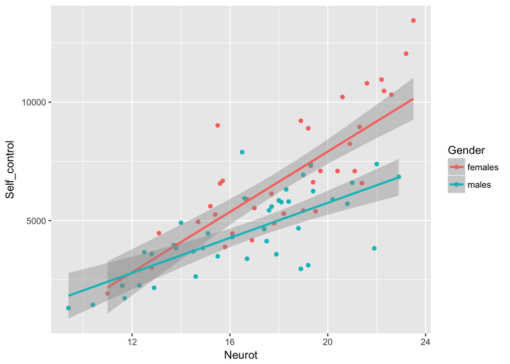

```r
p.neuro.gender <- ggplot(d, aes(x = Neurot, y = Self_control, color = Gender)) +
  stat_summary(fun.y = "mean", geom = "point") +
  geom_smooth(method = "lm")
p.neuro.gender
```

## Regressions

Note that neuroticism is NOT centered, so we will need to do that here. **Why?**

```r
d$Neurot.centered <- d$Neurot - mean(d$Neurot)
```

### Testing for interactions

```r
m.neurot.gender <- lm(Self_control ~ Neurot.centered * Gender, d)
summary(m.neurot.gender)
```

```
##
## Call:
## lm(formula = Self_control ~ Neurot.centered * Gender, data = d)
##
## Residuals:
##     Min      1Q  Median      3Q     Max
## -3290.1  -921.9  -131.4   949.3  3971.2
##
## Coefficients:
##                             Estimate Std. Error t value Pr(>|t|)
## (Intercept)                  6375.77     209.76  30.396  < 2e-16 ***
## Neurot.centered               637.21      64.34   9.904 2.39e-16 ***
## Gendermales                 -1517.90     296.62  -5.117 1.59e-06 ***
## Neurot.centered:Gendermales  -266.86      90.78  -2.940  0.00411 **
## ---
## Signif. codes:  0 '***' 0.001 '**' 0.01 '*' 0.05 '.' 0.1 ' ' 1
##
## Residual standard error: 1462 on 96 degrees of freedom
## Multiple R-squared:  0.6542, Adjusted R-squared:  0.6434
## F-statistic: 60.55 on 3 and 96 DF,  p-value: < 2.2e-16
```

### Testing simple slopes

Suppose we want to know the effect of gender on self-control for those who are highly neurotic – here, let’s define that as those who have neuroticism scores 2 standard deviations from the mean. **How would we do this?**

# Continuous x Continuous Interactions

## Plotting

Visualizing continuous x continuous interactions is quite difficult! I’ll show you a couple of strategies for visualizing the raw data. Then after we fit regression models we can make plots of the predictions as well.

### Option 1: Plot DV with color

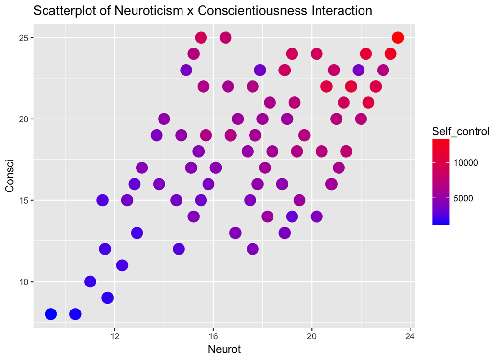

```r
p.neurot.consci <- ggplot(d, aes(x = Neurot, y = Consci, color = Self_control)) +
  geom_point(size = 5) +
  scale_color_gradient(low = "blue", high = "red") +
  ggtitle("Scatterplot of Neuroticism x Conscientiousness Interaction")
p.neurot.consci
```

### Option 2: Median Split

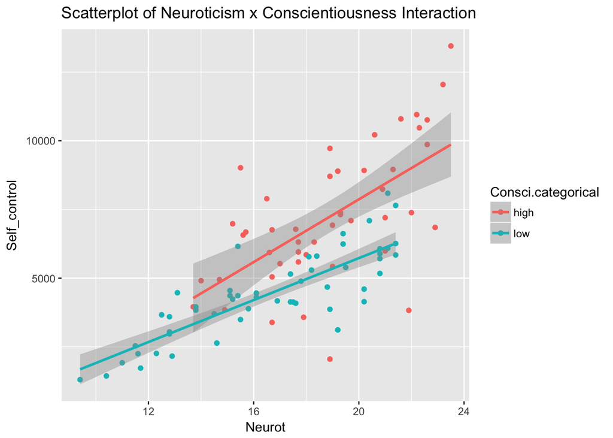

```r
d$Consci.categorical <- ifelse(d$Consci > median(d$Consci), "high", "low")
p.neurot.consci2 <- ggplot(d, aes(x = Neurot, y = Self_control, color = Consci.categorical)) +
  geom_point() +
  ggtitle("Scatterplot of Neuroticism x Conscientiousness Interaction") +
  geom_smooth(method = "lm")
p.neurot.consci2
```

### Option 3: 3D plot

```r
p.3d <- plot3d(d[, c("Consci", "Neurot", "Self_control")])
```

[output not shown]

## Regressions

Again, we’ll need to center the other continuous variable, `Consci`:

```r
d$Consci.centered <- d$Consci - mean(d$Consci)
```

### Testing for interactions

```r
m.consci.neurot <- lm(Self_control ~ Consci.centered * Neurot.centered, d)
summary(m.consci.neurot)
```

```
##
## Call:
## lm(formula = Self_control ~ Consci.centered * Neurot.centered,
##     data = d)
##
## Residuals:
##     Min      1Q  Median      3Q     Max
## -5756.2  -339.7    42.0   625.3  2399.7
##
## Coefficients:
##                                 Estimate Std. Error t value Pr(>|t|)
## (Intercept)                     5485.128    141.534  38.755  < 2e-16 ***
## Consci.centered                  338.321     40.707   8.311 6.21e-13 ***
## Neurot.centered                  368.216     47.622   7.732 1.04e-11 ***
## Consci.centered:Neurot.centered   29.727      8.485   3.504 0.000699 ***
## ---
## Signif. codes:  0 '***' 0.001 '**' 0.01 '*' 0.05 '.' 0.1 ' ' 1
##
## Residual standard error: 1289 on 96 degrees of freedom
## Multiple R-squared:  0.7313, Adjusted R-squared:  0.7229
## F-statistic: 87.09 on 3 and 96 DF,  p-value: < 2.2e-16
```

### Testing simple slopes

Let’s say that we want to know what the effect of neuroticism is for people who aren’t very conscientious.

```r
d$Consci.1sd <- d$Consci - (mean(d$Consci) - sd(d$Consci))
m.neurot.lowconsci <- lm(Self_control ~ Neurot.centered * Consci.1sd, d)
summary(m.neurot.lowconsci)
```

```
##
## Call:
## lm(formula = Self_control ~ Neurot.centered * Consci.1sd, data = d)
##
## Residuals:
##     Min      1Q  Median      3Q     Max
## -5756.2  -339.7    42.0   625.3  2399.7
##
## Coefficients:
##                            Estimate Std. Error t value Pr(>|t|)
## (Intercept)                4171.483    221.040  18.872  < 2e-16 ***
## Neurot.centered             252.790     53.653   4.712 8.30e-06 ***
## Consci.1sd                  338.321     40.707   8.311 6.21e-13 ***
## Neurot.centered:Consci.1sd   29.727      8.485   3.504 0.000699 ***
## ---
## Signif. codes:  0 '***' 0.001 '**' 0.01 '*' 0.05 '.' 0.1 ' ' 1
##
## Residual standard error: 1289 on 96 degrees of freedom
## Multiple R-squared:  0.7313, Adjusted R-squared:  0.7229
## F-statistic: 87.09 on 3 and 96 DF,  p-value: < 2.2e-16
```

## Plotting regression predictions

Now that we have a model of the continuous interaction, we can predict the slopes for a range of values!